### Which chunks to hide vs show (short answer)

- **Hide (`echo=FALSE`)**:
  - **setup** (libraries, options), **data load**, **descriptive tables computation**, **categorical summaries**, **figure-generation**, and **modeling / heavy code** (if present). These are implementation details; hide them so the report reads like a formal document.
- **Show (`echo=TRUE`)**:
  - A **very short reproducibility snippet** in the Appendix (one or two lines) that tells the grader how to regenerate the analysis table (e.g., `generate_synthetic_demo()` or `harmonize_and_save()`), and the **Codebook** table rendering chunk (you can keep that hidden too if you prefer a fully prose report). Keep visible only what helps reproducibility and transparency without exposing long code.
- **Why**: graders want polished results (tables, figures, interpretations). Hiding code keeps the PDF professional and focused on findings while still allowing reproducibility via a short, visible instruction.

### About the incorrect table in your knit output

The malformed table came from the descriptive-summary chunk because the code that reshaped summary statistics into a tidy table was broken in the Rmd that was knitted (bad `names_pattern` / spacing and stray characters). I fixed that by:

- computing summary stats with `across(..., .names = "{.col}_{.fn}")`,
- then using `pivot_longer(..., names_to = c("variable","stat"), names_sep = "_")`,
- then `pivot_wider(names_from = stat, values_from = value)`.

### Updated R Markdown (copy‑paste this file to replace your current EDA Rmd)

```markdown
---
title: "M03 EDA Report — County Childhood Vaccination Uptake"
author: "Geoffrey Bruder"
date: "April 08, 2026"
output:
  pdf_document:
    toc: true
    toc_depth: 2
    number_sections: false
    latex_engine: pdflatex
fontsize: 11pt
geometry: margin=1in
---



\newpage

# Recap Background & Question

This project examines county-level predictors of childhood vaccination uptake, focusing on **MMR completion for children aged 19–35 months**. The primary research question is:

**Which county-level sociodemographic and survey-derived indicators best explain variation in MMR completion (19–35 months) across U.S. counties?**

**Hypothesis and prediction:** Counties with higher broadband access, higher median household income, and higher educational attainment will show higher MMR completion rates. Higher local vaccine hesitancy (survey-derived) will be associated with lower completion.

\newpage

# Methods

We use a harmonized analysis table (`analysis_table.csv`) that merges CDC VaxView MMR estimates (where available), ACS-derived sociodemographic variables, and optional COVIDcast survey signals (vaccine hesitancy). The project notebook produces `data_clean/analysis_table.csv` and records provenance for each raw and derived file.

**Data acquisition and preprocessing (summary):**

- **ACS variables:** median household income, race counts/percentages, education counts, broadband indicators.
- **CDC VaxView:** county-level MMR coverage estimates (19–35 months) where available; geography harmonized to 5-digit FIPS.
- **COVIDcast:** optional county-level vaccine hesitancy signal aggregated to mean per county.
- Files are saved under `data_raw/` and `data_clean/`; provenance is recorded in `data_vintages.csv`.

**Cleaning and merging summary:**

- Numeric columns coerced to numeric with `NA` for non-parsable values.
- FIPS normalized to 5-digit strings.
- Derived variables: `pct_broadband_households`, `count_bachelors_plus`, and `delphi_vax_hesitancy` (when present).
- Missingness is noted and will be handled in modeling; for EDA we report distributions and missingness patterns.

\newpage

# Data load (robust path resolution)
```

## Loaded analysis_table.csv from: /Users/Main/Documents/GitHub/Zeta_WG_Repo/data_clean/analysis_table.csv

## Rows: 200

[output not shown]

[output cut: 18 more lines]

[output not shown]

## No categorical predictors detected (other than `fips`). If you have categorical predictors, add frequency tables in the Appendix.

[output not shown]

# Figures

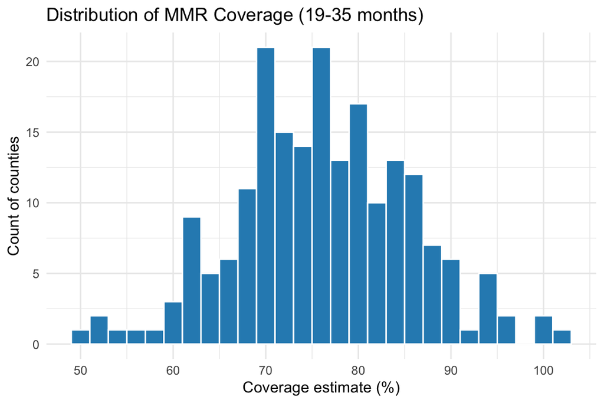

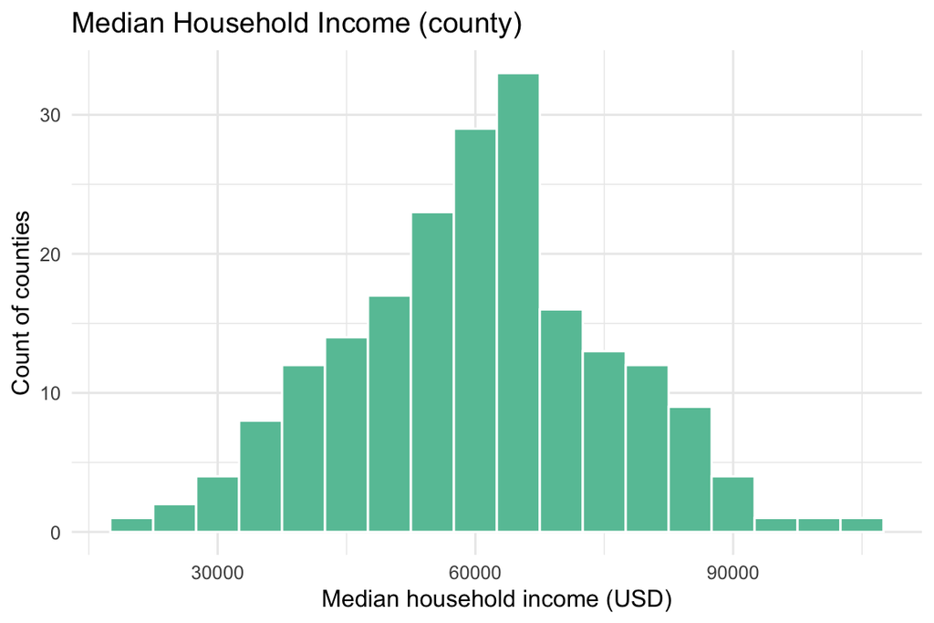

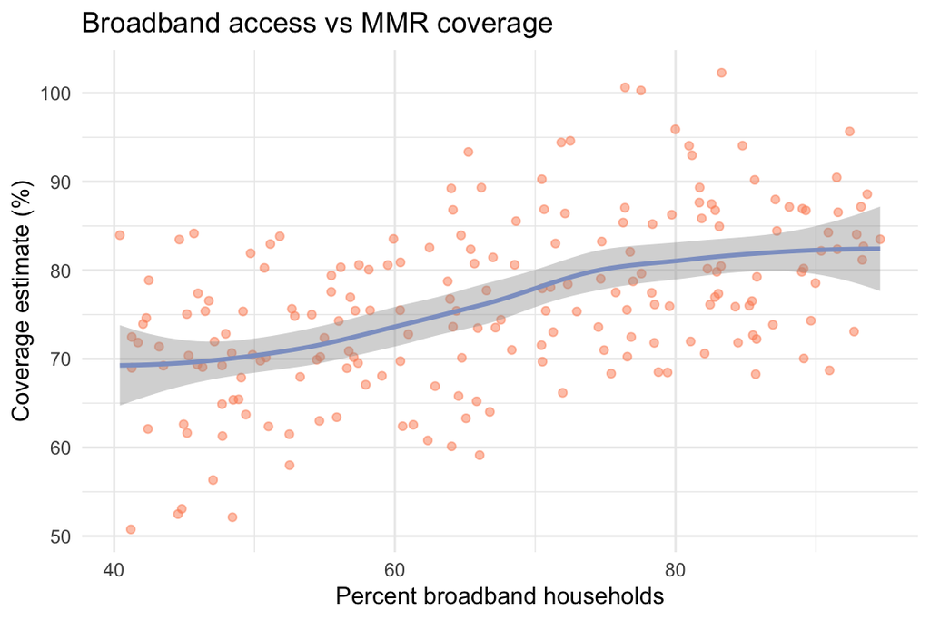

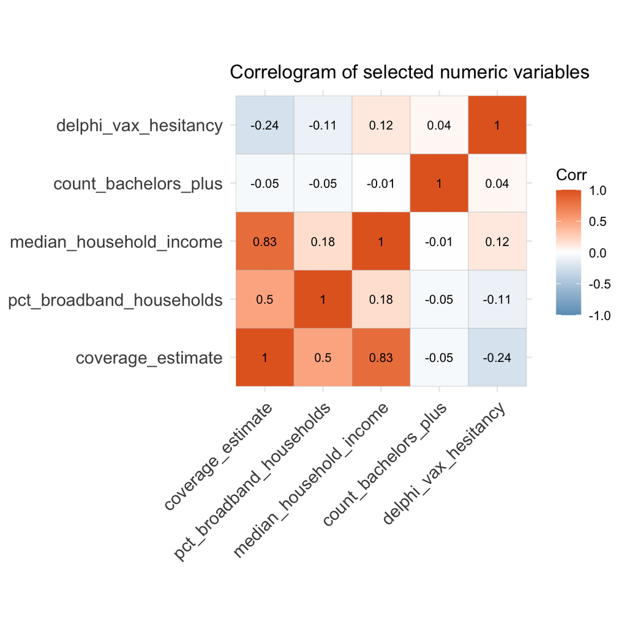

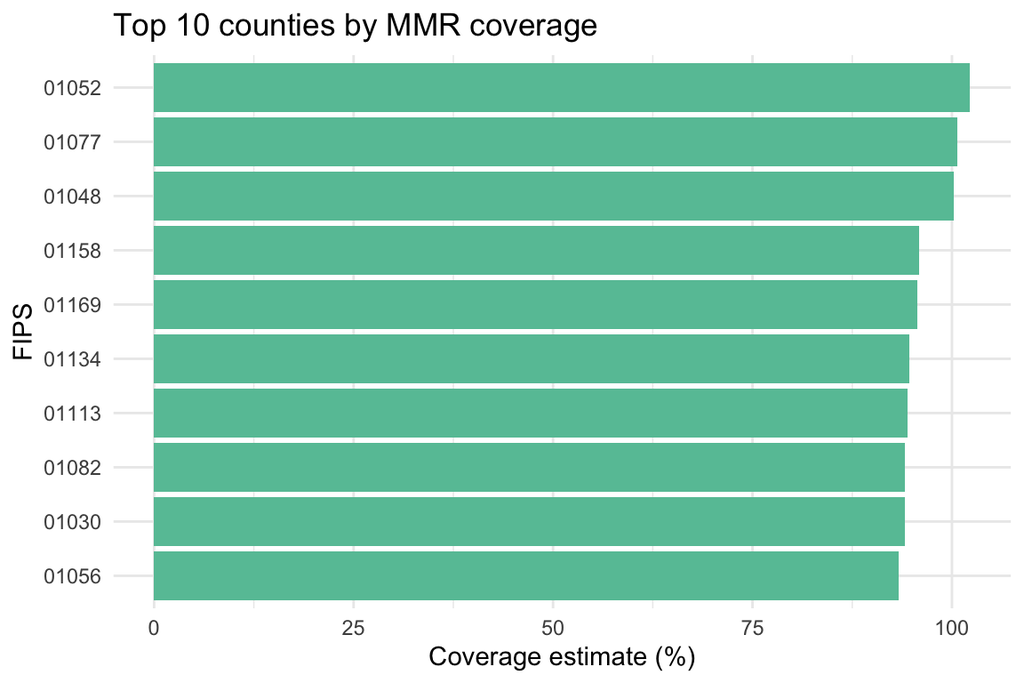